# Supplementary Figures

### Pollinator specialization imposes stronger evolutionary constraints to corolla shape

Simon Joly, François Lambert, Hermine Alexandre, Étienne Léveillé-Bourret, John L. Clark

*Submitted to Evolution*

## Supplementary Figure 1

Principal component analysis showing the corolla shape morphospace for all individuals. Pollination syndromes are shown by different colours. The large dots on the plot represent the species means and the individual floral shapes (small dots) are associated with their species mean by gray lines. Place your cursor over the points to get species and specimen information. You can also zoom in the figure.

[interactive chart not shown]

## Supplementary Figure 2

Principal component analysis showing the corolla shape morphospace for the individuals excluding the hummingbird pollinated species. Pollination syndromes are shown by different colours. The large dots on the plot represent the species means and the individual floral shapes (small dots) are associated with their species mean by gray lines. Place your cursor over the points to get species and specimen information. You can also zoom in the figure.

[interactive chart not shown]

## Supplementary Figure 3

Likelihood surface for different values of $\alpha$ and $\sigma^2$ when fitting a Ornstein-Uhlenbeck (OU) model on one tree from the posterior distribution of species trees.

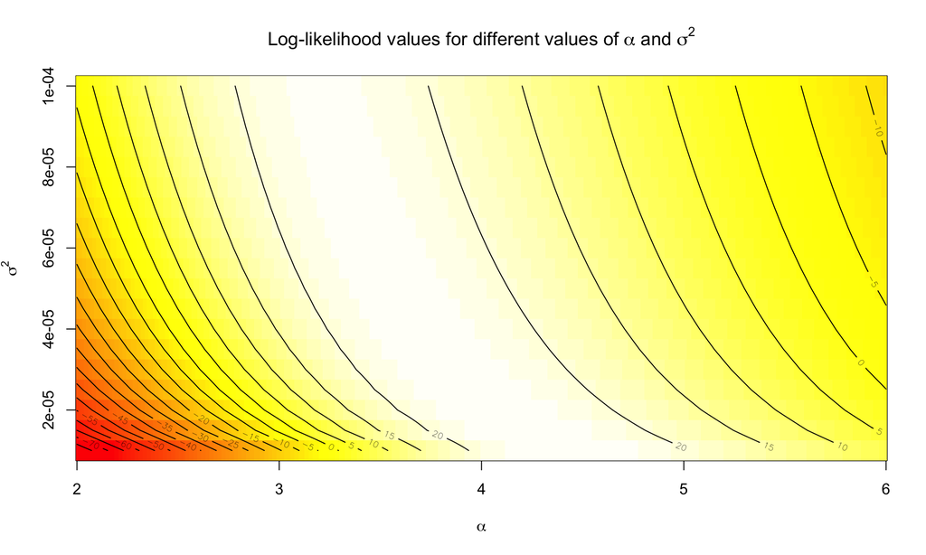

Figures generated with `R` with the libraries `plotly` `ggplot2`, and `knitr`.